# Análisis ETL: Ciclo Olímpico 2021-2024 en Natación

Autores/as

Alonso González Romero

Daniel López Paredes

Alba Martínez de la Hermosa

Fecha de publicación

11 de enero de 2026

# 1 Introducción

- Descripción del tema elegido
- Fuentes de datos
- Objetivos del análisis

Este proyecto presenta un flujo de trabajo ETL (Extract, Transform, Load) aplicado a datos oficiales de competiciones internacionales de natación entre 2021 y 2024. La **fuente de datos** proviene de los registros oficiales de [Omega Timing](https://www.omegatiming.com/), que proporciona a través de archivos XML información referente a múltiples competiciones de nivel internacional (Europeos, Mundiales, Trials Americanos, TYR Pro Swim Series, entre otros).

El **objetivo principal** del análisis es transformar los datos crudos en información procesable que permita responder preguntas clave sobre el rendimiento de los nadadores, tendencias temporales y comparativas entre diferentes competiciones y categorías.

# 2 Organización y Gestión del Proyecto

- Organización del Equipo
- Gestión de código
- Funciones desarrolladas

Para la gestión del código se ha utilizado Git como herramienta de control de versiones y GitHub como plataforma de colaboración y compartición de código. El repositorio se estructura en carpetas para separar los datos crudos de las competiciones de natación, los datos procesados para su estructura en CSV, los scripts de ETL y la documentación del proyecto.

Por otro lado, se ha utilizado Github Projects para la gestión de tareas y seguimiento del progreso del proyecto, elaborando un tablero *Kanban* con diferentes columnas: - To Do. Tareas pendientes por realizar. - In Progress. Tareas en desarrollo. - Done. Tareas finalizadas.

Además para el desarrollo modular y concurrente de las diferentes funcionalidades del proyecto, se han establecido diferentes ramas en el repositorio: - `main`: Rama principal con la versión estable del proyecto. - `develop`: Rama de desarrollo donde se integran las nuevas funcionalidades antes de ser fusionadas a `main`. - `feature/nombre-funcionalidad`: Ramas específicas para el desarrollo de nuevas características o mejoras.

Para cada issue creado en GitHub Projects, se le asigna un Pull Request (PR) asociado, que es revisado por al menos otro miembro del equipo antes de ser fusionado a la rama `develop` o `main`. Esto asegura la calidad del código y facilita la colaboración entre los miembros del equipo. En la Figura 1 se puede observar el tablero mencionado junto con los issues vinculados a cada tarea. Una vez completado el merge de la feature branch a develop o main, el issue se mueve a la columna Done junto con el PR cerrado.

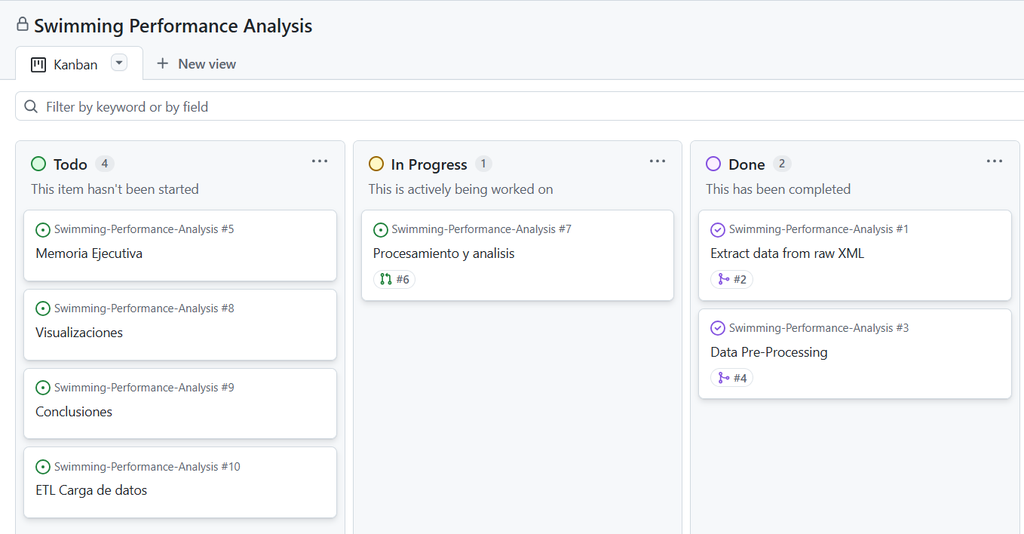

Figura 1: Tablero Kanban con issues gestionados en GitHub Projects.

# 3 Extracción de Datos

## 3.1 Importación de fuente de datos

Como bien se ha adelantado en la sección Introducción, los datos han sido extraídos de los archivos XML oficiales proporcionados por Omega Timing. Tras un proceso previo de scraping y parseo de archivos XML, hemos consolidado la información en cuatro archivos CSV que conforman nuestra base de datos relacional:

- `competiciones.csv`: Información sobre las competiciones cargadas.
- `atletas.csv`: Detalles de los nadadores.
- `clubes.csv`: Datos de los clubes/países.
- `resultados.csv`: Resultados de las competiciones nadadas.

A continuación, procedemos a la carga de estos archivos en el entorno de trabajo utilizando la librería `pandas` de Python y un manejo básico de errores para asegurar que los archivos se cargan correctamente:

```python
import pandas as pd
import os

BASE_PATH = 'data/processed_data/'

path_atletas = f'{BASE_PATH}atletas.csv'
path_clubes = f'{BASE_PATH}clubes.csv'
path_competiciones = f'{BASE_PATH}competiciones.csv'
path_resultados = f'{BASE_PATH}resultados.csv'

# Carga de DataFrames
try:
    df_atletas = pd.read_csv(path_atletas)
    df_clubes = pd.read_csv(path_clubes)
    df_competiciones = pd.read_csv(path_competiciones)
    df_resultados = pd.read_csv(path_resultados)

    print("Todos los archivos se han cargados correctamente.")
except FileNotFoundError as e:
    print(f"Error de carga: {e}")

# Eliminamos las rutas de los archivos para no sobrecargar el entorno
del path_atletas, path_clubes, path_competiciones, path_resultados, BASE_PATH
```

```
Todos los archivos se han cargados correctamente.
```

## 3.2 Exploración inicial

Una vez cargados los datos, realizamos una exploración inicial de cada DataFrame para entender su estructura, los tipos de datos y la integridad de los identificadores. Para sistematizar este proceso de exploración, hemos desarrollado las siguientes funciones:

- `explorar_estructura(df, nombre_df, filas=3)`: Muestra las dimensiones, tipos de datos y un ejemplo de las primeras N filas de la tabla. Si no se especifica la última variable, se muestran las primeras 3 filas por defecto.
- `verificar_unicidad(df, col_id)`: Verifica si una columna específica actúa como identificador único (Clave Primaria).

```python
def explorar_estructura(df, nombre_df, filas=3):
    """
    Datos de entrada:
    - df: DataFrame a explorar.
    - nombre_df: Nombre descriptivo del DataFrame. (String)
    - filas: Número de filas a mostrar del DataFrame. (Integer, default=3)

    Funcionalidad:
    Muestra las dimensiones, tipos de datos y un ejemplo de las primeras filas.
    """
    print(f"### Estructura del dataset: {nombre_df}")
    print(f"Dimensiones: {df.shape[0]} filas x {df.shape[1]} columnas")

    # Creamos un resumen rápido de tipos
    print("\n--- Tipos de datos ---")
    print(df.dtypes)

    print(f"\n--- Primeras {filas} filas de {nombre_df} ---")
    display(df.head(filas))
    print("\n" + "="*50 + "\n")

def verificar_unicidad(df, col_id):
    """
    Datos de entrada:
    - df: DataFrame a explorar.
    - col_id: Nombre de la columna a verificar como identificador único. (String)

    Funcionalidad:
    Verifica si una columna específica actúa como identificador único para esa tabla.
    """
    print(f"Verificando identificador '{col_id}':")

    try:
        serie = df[col_id]
        if serie.is_unique:
            print(f"La columna '{col_id}' es un identificador único en el DataFrame.")
        else:
            total = len(df)
            unicos = serie.nunique()
            print(f"La columna '{col_id}' NO es un identificador único. Tiene {unicos} valores únicos de {total} registros.")

    except KeyError:
        print(f"ERROR DE ACCESO: La columna '{col_id}' no existe en el DataFrame.")

    except Exception as e:
        # Captura cualquier otro error inesperado (por ejemplo, dataframe corrupto)
        print(f"ERROR INESPERADO: {e}")

    finally:
        # El bloque finally se ejecuta SIEMPRE, haya error o no. Ideal para formato.
        print("-" * 30)
```

### 3.2.1 Atletas

Comenzamos con el DataFrame `df_atletas`, que contiene información sobre los nadadores. Analizamos primeramente su estructura:

```python
explorar_estructura(df_atletas, 'ID', filas=5)
```

```
### Estructura del dataset: ID
Dimensiones: 4710 filas x 5 columnas

--- Tipos de datos ---
ID            int64
NOMBRE       object
APELLIDOS    object
birthday     object
género       object
dtype: object

--- Primeras 5 filas de ID ---
```

|  | ID | NOMBRE | APELLIDOS | birthday | género |
| --- | --- | --- | --- | --- | --- |
| 0 | 164222 | Fahim | ANWARI | 1999-05-05 | M |
| 1 | 162857 | Paolo | PRISKA | 2004-09-15 | M |
| 2 | 226492 | Grisi | KOXHAKU | 2006-03-24 | M |
| 3 | 247922 | Arla | DERMISHI | 2010-01-29 | F |
| 4 | 213888 | Kaltra | MECA | 2008-03-26 | F |

Se puede observar que el DataFrame `df_atletas` tiene 4,700 filas y 5 columnas. Para cada nadador, se registra su identificador (`ID`), su nombre (`NOMBRE`), sus apellidos (`APELLIDOS`), su fecha de nacimiento (`birthday`) y su género (`género`).

Verificamos si la columna `ID` es un identificador único para este DataFrame:

```python
verificar_unicidad(df_atletas, 'ID')
```

```
Verificando identificador 'ID':
La columna 'ID' es un identificador único en el DataFrame.
------------------------------
```

Por lo tanto, podemos concluir que en el DataFrame `df_atletas`, la columna `ID` actúa como clave primaria y no hay errores en la carga.

### 3.2.2 Clubes

Procedemos de manera similar con el Dataframe `df_clubes`, que contiene información sobre los clubes o países a los que pertenecen los nadadores.

```python
explorar_estructura(df_clubes, 'Clubes')
```

```
### Estructura del dataset: Clubes
Dimensiones: 1013 filas x 3 columnas

--- Tipos de datos ---
club_code      object
club_name      object
club_nation    object
dtype: object

--- Primeras 3 filas de Clubes ---
```

|  | club_code | club_name | club_nation |
| --- | --- | --- | --- |
| 0 | AFG | Afghanistan | AFG |
| 1 | ALB | Albania | ALB |
| 2 | ALG | Algeria | ALG |

Verificamos si la columna `club_code` es un identificador único para este DataFrame:

```python
verificar_unicidad(df_clubes, 'club_code')
```

```
Verificando identificador 'club_code':
La columna 'club_code' es un identificador único en el DataFrame.
------------------------------
```

Por lo tanto, podemos concluir que en el DataFrame `df_clubes`, la columna `club_code` actúa como clave primaria y no hay errores en la carga.

### 3.2.3 Competiciones

Procedemos de manera similar con el Dataframe `df_competiciones`, que contiene información sobre las competiciones de natación.

```python
explorar_estructura(df_competiciones, 'Competiciones')
```

```
### Estructura del dataset: Competiciones
Dimensiones: 21 filas x 9 columnas

--- Tipos de datos ---
ID               int64
nombre          object
ciudad          object
tipo_piscina    object
fecha_inicio    object
fecha_fin       object
pais            object
cronometraje    object
numeroCalles     int64
dtype: object

--- Primeras 3 filas de Competiciones ---
```

|  | ID | nombre | ciudad | tipo_piscina | fecha_inicio | fecha_fin | pais | cronometraje | numeroCalles |
| --- | --- | --- | --- | --- | --- | --- | --- | --- | --- |
| 0 | 1 | World Aquatics Championships | Doha | LCM | 2024-02-11 | 2024-02-18 | QAT | AUTOMATIC | 10 |
| 1 | 2 | World Aquatics Junior Swimming Championships | Netanya | LCM | 2023-09-04 | 2023-09-09 | ISR | AUTOMATIC | 10 |
| 2 | 3 | 2023 Toyota US Open Championships | Greensboro, NC | LCM | 2023-11-29 | 2023-12-02 | USA | AUTOMATIC | 9 |

El DataFrame `df_competiciones` tiene 21 filas y 9 columnas. Cada registro contiene el identificador de la competición (`ID`), el nombre de la competición (`nombre`), la ciudad donde se celebró (`ciudad`), el tipo de piscina (`tipo_piscina`), el país (`pais`) y las fechas de inicio y fin (`fecha_inicio`, `fecha_fin`), el tipo de cronometraje (`cronometraje`) y el número de calles (`numeroCalles`).

Verificamos si la columna `ID` es un identificador único para este DataFrame:

```python
verificar_unicidad(df_competiciones, 'ID')
```

```
Verificando identificador 'ID':
La columna 'ID' es un identificador único en el DataFrame.
------------------------------
```

Por lo tanto, podemos concluir que en el DataFrame `df_competiciones`, la columna `ID` actúa como clave primaria y no hay errores en la carga.

### 3.2.4 Resultados

Procedemos de manera similar con el Dataframe `df_resultados`, que contiene información sobre los resultados de las competiciones.

```python
explorar_estructura(df_resultados, 'Resultados', 5)
```

```
### Estructura del dataset: Resultados
Dimensiones: 179696 filas x 13 columnas

--- Tipos de datos ---
id_competicion         int64
id_atleta              int64
club_code             object
distancia              int64
estilo                object
ronda                 object
tiempo_final          object
descalificado?        object
puntos               float64
distancia_parcial    float64
tiempo_acumulado      object
fecha                 object
hora                  object
dtype: object

--- Primeras 5 filas de Resultados ---
```

|  | id_competicion | id_atleta | club_code | distancia | estilo | ronda | tiempo_final | descalificado? | puntos | distancia_parcial | tiempo_acumulado | fecha | hora |
| --- | --- | --- | --- | --- | --- | --- | --- | --- | --- | --- | --- | --- | --- |
| 0 | 1 | 164222 | AFG | 100 | BREAST | PRE | 00:01:10.86 | No | 517.0 | 50.0 | 00:00:33.20 | 2024-02-11 | 11:15 |
| 1 | 1 | 164222 | AFG | 100 | BREAST | PRE | 00:01:10.86 | No | 517.0 | 100.0 | 00:01:10.86 | 2024-02-11 | 11:15 |
| 2 | 1 | 164222 | AFG | 50 | BREAST | PRE | 00:00:31.83 | No | 541.0 | 50.0 | 00:00:31.83 | 2024-02-13 | 09:33 |
| 3 | 1 | 162857 | ALB | 100 | FLY | PRE | 00:00:59.01 | No | 588.0 | 50.0 | 00:00:27.10 | 2024-02-16 | 09:38 |
| 4 | 1 | 162857 | ALB | 100 | FLY | PRE | 00:00:59.01 | No | 588.0 | 100.0 | 00:00:59.01 | 2024-02-16 | 09:38 |

Se observa que el DataFrame `df_resultados` tiene 179696 filas y 13 columnas. Cada registro contiene variables significantes para los resultados como el identificador de la competición (`id_competicion`), el identificador del nadador (`id_atleta`), el identificador del club o país (`club_code`), y datos sobre la prueba nadada, la ronda, el tiempo realizado, la fecha y hora a la que nadó, entre otros. Cabe destacar el formato en el que se presentan los resultados, ya que, por cada parcial que nadó el nadador, se genera un registro independiente en el DataFrame. Es por ello que, como se puede observar, las 2 primeras filas del DataFrame corresponden al resultado del nadador con id 16422 en el 100 BREAST de la ronda PRE, donde la primera fila contiene información sobre el paso por el primer parcial (50m) y la segunda fila contiene el tiempo acumulado en el paso por el segundo y último parcial (100m).

# 4 Pre-procesamiento

Tras la exploración inicial de los datos, procedemos a la fase de pre-procesamiento, donde vamos a realizar las siguientes tareas:

- Tratamiento de tipos de datos en las columnas
- Manejo de valores nulos
- Transformación de fechas
- Transformaciones de texto
- Creación de variables derivadas

## 4.1 Funciones Auxiliares

Para llevar a cabo el pre-procesamiento de manera sistemática y reutilizable, hemos desarrollado las siguientes funciones:

- `verificar_nulos(df, nombre_df)`: Detecta y cuantifica valores faltantes en cada columna.
- `cambiar_tipos_datos(df, mapeo_tipos)`: Convierte tipos de datos según un diccionario especificado.
- `limpiar_espacios_blancos(df)`: Elimina espacios en blanco al inicio y final de valores texto.
- `transformar_fechas(df, columnas_fechas, columna_hora)`: Convierte columnas de fecha (y hora opcionalmente) a formato datetime.
- `mostrar_resumen_preprocesamiento(df, nombre_df)`: Muestra un resumen del estado del DataFrame tras el pre-procesamiento.

```python
def verificar_nulos(df, nombre_df):
    """
    Datos de entrada:
    - df: DataFrame a analizar.
    - nombre_df: Nombre descriptivo del DataFrame. (String)

    Funcionalidad:
    Detecta y cuantifica valores nulos/faltantes en cada columna del DataFrame.
    """
    print(f"### Análisis de Valores Nulos: {nombre_df}")

    nulos_por_columna = df.isnull().sum()
    porcentaje_nulos = (df.isnull().sum() / len(df)) * 100

    if nulos_por_columna.sum() == 0:
        print("No se detectaron valores nulos en el DataFrame.")
    else:
        resumen_nulos = pd.DataFrame({
            'Columna': nulos_por_columna.index,
            'Cantidad': nulos_por_columna.values,
            'Porcentaje': porcentaje_nulos.values
        })
        resumen_nulos = resumen_nulos[resumen_nulos['Cantidad'] > 0].sort_values('Cantidad', ascending=False)
        print(resumen_nulos.to_string(index=False))

    print("-" * 50)

def cambiar_tipos_datos(df, mapeo_tipos):
    """
    Datos de entrada:
    - df: DataFrame a transformar.
    - mapeo_tipos: Diccionario con columnas y sus tipos destino. (Dict)

    Funcionalidad:
    Convierte el tipo de datos de las columnas especificadas.
    """
    print("### Conversión de Tipos de Datos")

    for columna, tipo in mapeo_tipos.items():
        if columna in df.columns:
            try:
                df[columna] = df[columna].astype(tipo)
                print(f"✓ Columna '{columna}' convertida a {tipo.__name__}")
            except Exception as e:
                print(f"✗ Error al convertir '{columna}': {e}")
        else:
            print(f"⚠ Columna '{columna}' no encontrada en el DataFrame.")

    print("-" * 50)
    return df

def limpiar_espacios_blancos(df):
    """
    Datos de entrada:
    - df: DataFrame a limpiar.

    Funcionalidad:
    Elimina espacios en blanco al inicio y final de valores de texto.
    """
    print("### Limpieza de Espacios en Blanco")

    columnas_procesadas = 0
    for columna in df.select_dtypes(include=['object']).columns:
        df[columna] = df[columna].str.strip()
        columnas_procesadas += 1

    print(f"Se procesaron {columnas_procesadas} columnas de tipo texto.")
    print("-" * 50)
    return df

def transformar_fechas(df, columnas_fechas, columna_hora=None):
    """
    Datos de entrada:
    - df: DataFrame a transformar.
    - columnas_fechas: Lista de columnas a convertir a datetime. (List)
    - columna_hora: (Opcional) Columna con hora para combinar con la primera fecha. (String)

    Funcionalidad:
    Convierte columnas especificadas al formato datetime.
    Si se proporciona columna_hora, combina fecha + hora en una nueva columna 'fecha_hora'.
    """
    print("### Transformación de Fechas")

    for columna in columnas_fechas:
        if columna in df.columns:
            try:
                df[columna] = pd.to_datetime(df[columna], errors='coerce')
                print(f"✓ Columna '{columna}' convertida a datetime")
            except Exception as e:
                print(f"✗ Error al convertir '{columna}': {e}")
        else:
            print(f"⚠ Columna '{columna}' no encontrada.")

    # Si se proporciona una columna de hora, combinar fecha + hora
    if columna_hora and columna_hora in df.columns and len(columnas_fechas) > 0:
        columna_fecha = columnas_fechas[0]
        if columna_fecha in df.columns:
            try:
                df['fecha_hora'] = pd.to_datetime(
                    df[columna_fecha].astype(str) + ' ' + df[columna_hora].astype(str),
                    format='%Y-%m-%d %H:%M:%S',
                    errors='coerce'
                )
                print(f"✓ Columna 'fecha_hora' creada combinando '{columna_fecha}' y '{columna_hora}'")
            except Exception as e:
                print(f"✗ Error al combinar fecha y hora: {e}")

    print("-" * 50)
    return df

def mostrar_resumen_preprocesamiento(df, nombre_df):
    """
    Datos de entrada:
    - df: DataFrame procesado.
    - nombre_df: Nombre descriptivo del DataFrame. (String)

    Funcionalidad:
    Muestra un resumen del estado actual del DataFrame.
    """
    print(f"### Resumen Post-Procesamiento: {nombre_df}")
    print(f"Dimensiones: {df.shape[0]} filas x {df.shape[1]} columnas")
    print(f"Valores nulos totales: {df.isnull().sum().sum()}")
    print("\n--- Tipos de datos ---")
    print(df.dtypes)
    print("\n" + "="*50 + "\n")
```

## 4.2 Tratamiento de Tipos de Datos

Comenzamos transformando los tipos de datos de las columnas para asegurar que cada variable tiene el formato adecuado para análisis posterior.

### 4.2.1 Atletas

```python
# Definimos el mapeo de tipos para df_atletas
tipos_atletas = {
    'ID': int,
    'NOMBRE': str,
    'APELLIDOS': str,
    'birthday': str,  # Convertiremos a datetime en el siguiente paso
    'género': str
}

df_atletas = cambiar_tipos_datos(df_atletas, tipos_atletas)
```

```
### Conversión de Tipos de Datos
✓ Columna 'ID' convertida a int
✓ Columna 'NOMBRE' convertida a str
✓ Columna 'APELLIDOS' convertida a str
✓ Columna 'birthday' convertida a str
✓ Columna 'género' convertida a str
--------------------------------------------------
```

### 4.2.2 Clubes

```python
# Definimos el mapeo de tipos para df_clubes
tipos_clubes = {
    'club_code': str,
    'club_name': str,
    'club_nation': str
}

df_clubes = cambiar_tipos_datos(df_clubes, tipos_clubes)
```

```
### Conversión de Tipos de Datos
✓ Columna 'club_code' convertida a str
✓ Columna 'club_name' convertida a str
✓ Columna 'club_nation' convertida a str
--------------------------------------------------
```

### 4.2.3 Competiciones

```python
# Definimos el mapeo de tipos para df_competiciones
tipos_competiciones = {
    'ID': int,
    'nombre': str,
    'ciudad': str,
    'tipo_piscina': str,
    'pais': str,
    'fecha_inicio': str,  # Convertiremos a datetime después
    'fecha_fin': str,     # Convertiremos a datetime después
    'cronometraje': str,
    'numeroCalles': int
}

df_competiciones = cambiar_tipos_datos(df_competiciones, tipos_competiciones)
```

```
### Conversión de Tipos de Datos
✓ Columna 'ID' convertida a int
✓ Columna 'nombre' convertida a str
✓ Columna 'ciudad' convertida a str
✓ Columna 'tipo_piscina' convertida a str
✓ Columna 'pais' convertida a str
✓ Columna 'fecha_inicio' convertida a str
✓ Columna 'fecha_fin' convertida a str
✓ Columna 'cronometraje' convertida a str
✓ Columna 'numeroCalles' convertida a int
--------------------------------------------------
```

### 4.2.4 Resultados

```python
# Definimos el mapeo de tipos para df_resultados
tipos_resultados = {
    'id_competicion': int,
    'id_atleta': int,
    'club_code': str,
    'distancia': int,
    'estilo': str,
    'ronda': str,
    'tiempo_final': str,  # Lo transformaremos en la sección de transformaciones
    'descalificado?': str,
    'puntos': int,
    'distancia_parcial': int,
    'tiempo_acumulado': str,
    'fecha': str,  # Convertiremos a datetime después
    'hora': str    # Convertiremos a datetime después
}

df_resultados = cambiar_tipos_datos(df_resultados, tipos_resultados)
```

```
### Conversión de Tipos de Datos
✓ Columna 'id_competicion' convertida a int
✓ Columna 'id_atleta' convertida a int
✓ Columna 'club_code' convertida a str
✓ Columna 'distancia' convertida a int
✓ Columna 'estilo' convertida a str
✓ Columna 'ronda' convertida a str
✓ Columna 'tiempo_final' convertida a str
✓ Columna 'descalificado?' convertida a str
✗ Error al convertir 'puntos': Cannot convert non-finite values (NA or inf) to integer
✗ Error al convertir 'distancia_parcial': Cannot convert non-finite values (NA or inf) to integer
✓ Columna 'tiempo_acumulado' convertida a str
✓ Columna 'fecha' convertida a str
✓ Columna 'hora' convertida a str
--------------------------------------------------
```

## 4.3 Manejo de Valores Nulos

Realizamos un análisis exhaustivo de valores faltantes en cada DataFrame y decidimos cómo tratarlos.

### 4.3.1 Atletas

```python
verificar_nulos(df_atletas, 'Atletas')
```

```
### Análisis de Valores Nulos: Atletas
No se detectaron valores nulos en el DataFrame.
--------------------------------------------------
```

### 4.3.2 Clubes

```python
verificar_nulos(df_clubes, 'Clubes')
```

```
### Análisis de Valores Nulos: Clubes
No se detectaron valores nulos en el DataFrame.
--------------------------------------------------
```

### 4.3.3 Competiciones

```python
verificar_nulos(df_competiciones, 'Competiciones')
```

```
### Análisis de Valores Nulos: Competiciones
No se detectaron valores nulos en el DataFrame.
--------------------------------------------------
```

### 4.3.4 Resultados

```python
verificar_nulos(df_resultados, 'Resultados')
```

```
### Análisis de Valores Nulos: Resultados
          Columna  Cantidad  Porcentaje
           puntos     74754   41.600258
distancia_parcial      1972    1.097409
--------------------------------------------------
```

## 4.4 Limpieza de Espacios en Blanco

Aseguramos la eliminación de posibles espacios en blanco superfluos en las columnas de texto de todos los DataFrames.

```python
df_atletas = limpiar_espacios_blancos(df_atletas)
df_clubes = limpiar_espacios_blancos(df_clubes)
df_competiciones = limpiar_espacios_blancos(df_competiciones)
df_resultados = limpiar_espacios_blancos(df_resultados)
```

```
### Limpieza de Espacios en Blanco
Se procesaron 4 columnas de tipo texto.
--------------------------------------------------
### Limpieza de Espacios en Blanco
Se procesaron 3 columnas de tipo texto.
--------------------------------------------------
### Limpieza de Espacios en Blanco
Se procesaron 7 columnas de tipo texto.
--------------------------------------------------
### Limpieza de Espacios en Blanco
Se procesaron 8 columnas de tipo texto.
--------------------------------------------------
```

## 4.5 Transformación de Fechas

Convertimos las columnas de fechas al formato `datetime` para facilitar análisis temporales.

### 4.5.1 Atletas

```python
# Convertimos la fecha de nacimiento
df_atletas = transformar_fechas(df_atletas, ['birthday'])

# Renombramos la columna para mayor claridad
df_atletas.rename(columns={'birthday': 'fecha_nacimiento'}, inplace=True)
```

```
### Transformación de Fechas
✓ Columna 'birthday' convertida a datetime
--------------------------------------------------
```

### 4.5.2 Competiciones

```python
# Convertimos las fechas de inicio y fin de las competiciones
df_competiciones = transformar_fechas(df_competiciones, ['fecha_inicio', 'fecha_fin'])
```

```
### Transformación de Fechas
✓ Columna 'fecha_inicio' convertida a datetime
✓ Columna 'fecha_fin' convertida a datetime
--------------------------------------------------
```

### 4.5.3 Resultados

```python
# Convertimos la fecha y hora de los resultados
df_resultados = transformar_fechas(df_resultados, ['fecha'], columna_hora='hora')
```

```
### Transformación de Fechas
✓ Columna 'fecha' convertida a datetime
✓ Columna 'fecha_hora' creada combinando 'fecha' y 'hora'
--------------------------------------------------
```

Al disponer de la fecha y hora, la función nos devuelve el datetime completo en la columna `fecha_hora`.

## 4.6 Transformaciones de Texto

Realizamos transformaciones en variables de texto para estandarizarlas y mejorar su calidad.

### 4.6.1 Normalización de Géneros

```python
# Verificamos valores únicos antes de la transformación
print(f"Valores únicos en 'género': {df_atletas['género'].unique()}")

# Estandarizamos los valores (Hombre/Mujer, H/M, etc.)
df_atletas['género'] = df_atletas['género'].str.upper()
df_atletas['género'] = df_atletas['género'].replace({
    'M': 'HOMBRE',
    'F': 'MUJER',
    'MALE': 'HOMBRE',
    'FEMALE': 'MUJER'
})

print(f"Valores normalizados: {df_atletas['género'].unique()}")
print("-" * 50)
```

```
Valores únicos en 'género': ['M' 'F']
Valores normalizados: ['HOMBRE' 'MUJER']
--------------------------------------------------
```

Como los valores para género son únicos y correctos (no existen valores diferentes o en minúsculas), no es necesario realizar ninguna transformación adicional.

### 4.6.2 Normalización de Pruebas y Rondas

```python
print("### Normalización de Pruebas y Rondas")

# Convertimos a mayúsculas para estandarización
df_resultados['estilo'] = df_resultados['estilo'].str.upper()
df_resultados['ronda'] = df_resultados['ronda'].str.upper()

print(f"Pruebas únicas (primeras 10): {df_resultados['estilo'].unique()[:10]}")
print(f"Rondas únicas: {df_resultados['ronda'].unique()}")
print("-" * 50)
```

```
### Normalización de Pruebas y Rondas
Pruebas únicas (primeras 10): ['BREAST' 'FLY' 'FREE' 'MEDLEY' 'BACK']
Rondas únicas: ['PRE' 'SEM' 'FIN' 'SOP' 'SOS' 'FHT']
--------------------------------------------------
```

Se asegura la unicidad de los valores en las columnas `estilo` y `ronda` tras la normalización transformando las cadenas de texto en mayúsculas.

## 4.7 Creación de Variables Derivadas

Creamos nuevas variables que serán útiles para el análisis posterior.

### 4.7.1 Duración de Competiciones

```python
print("### Creación de Variable: Duración de Competiciones")

# Calculamos la duración en días de cada competición
df_competiciones['duracion_dias'] = (df_competiciones['fecha_fin'] - df_competiciones['fecha_inicio']).dt.days + 1

print(f"Duración mínima: {df_competiciones['duracion_dias'].min()} días")
print(f"Duración máxima: {df_competiciones['duracion_dias'].max()} días")
print(f"Duración promedio: {df_competiciones['duracion_dias'].mean():.1f} días")
print("-" * 50)
```

```
### Creación de Variable: Duración de Competiciones
Duración mínima: 4 días
Duración máxima: 9 días
Duración promedio: 5.5 días
--------------------------------------------------
```

### 4.7.2 Parseo de Tiempos

```python
def parse_resultados_temporal(df):
    # trabajar sobre copia
    df = df.copy()
    # Normalizar separador decimal en las columnas de tiempo (si hubiera comas)
    df['tiempo_final'] = df['tiempo_final'].astype(str).str.replace(',', '.', regex=False)
    df['tiempo_acumulado'] = df.get('tiempo_acumulado', pd.Series(dtype=str)).astype(str).str.replace(',', '.', regex=False)

    # Combinar fecha + hora -> datetime (ajusta format si tu formato difiere)
    df['fecha_hora'] = pd.to_datetime(
        df['fecha'].astype(str) + ' ' + df['hora'].astype(str),
        format='%Y-%m-%d %H:%M',
        errors='coerce'
    )

    # Convertir tiempos "HH:MM:SS.ss" a Timedelta y después a segundos (float)
    df['tiempo_final_td'] = pd.to_timedelta(df['tiempo_final'], errors='coerce')
    df['tiempo_final_seg'] = df['tiempo_final_td'].dt.total_seconds()

    if 'tiempo_acumulado' in df.columns:
        df['tiempo_acumulado_td'] = pd.to_timedelta(df['tiempo_acumulado'], errors='coerce')
        df['tiempo_acumulado_seg'] = df['tiempo_acumulado_td'].dt.total_seconds()

    # Extracción de variables temporales (evitar acentos en nombres de columna)
    df['anio_competicion'] = df['fecha_hora'].dt.year
    df['mes_competicion'] = df['fecha_hora'].dt.month
    df['dia_semana'] = df['fecha_hora'].dt.day_name()

    return df

# Aplicamos la función a la columna de tiempos
df_resultados = parse_resultados_temporal(df_resultados)

print(f"Tiempos convertidos exitosamente")
print(f"Tiempo mínimo final: {df_resultados['tiempo_final_seg'].min():.2f} segundos")
print(f"Tiempo máximo final: {df_resultados['tiempo_final_seg'].max():.2f} segundos")
print(f"Tiempos finales faltantes: {df_resultados['tiempo_final_seg'].isnull().sum()}")

print(f"Tiempo mínimo acumulado: {df_resultados['tiempo_acumulado_seg'].min():.2f} segundos")
print(f"Tiempo máximo acumulado: {df_resultados['tiempo_acumulado_seg'].max():.2f} segundos")
print(f"Tiempos acumulados faltantes: {df_resultados['tiempo_acumulado_seg'].isnull().sum()}")
print("-" * 50)
```

```
Tiempos convertidos exitosamente
Tiempo mínimo final: 21.04 segundos
Tiempo máximo final: 1169.09 segundos
Tiempos finales faltantes: 1680
Tiempo mínimo acumulado: 21.04 segundos
Tiempo máximo acumulado: 1169.09 segundos
Tiempos acumulados faltantes: 2065
--------------------------------------------------
```

### 4.7.3 Extracción de Información Temporal

```python
print("### Extracción de Variables Temporales")

# Extraemos el año de las competiciones
df_resultados['anio_competicion'] = df_resultados['fecha'].dt.year
df_resultados['mes_competicion'] = df_resultados['fecha'].dt.month
df_resultados['dia_semana'] = df_resultados['fecha'].dt.day_name()

# Extraemos también de las competiciones
df_competiciones['anio'] = df_competiciones['fecha_inicio'].dt.year

print(f"Años en competiciones: {sorted(df_competiciones['anio'].unique())}")
print(f"Meses representados: {sorted(df_resultados['mes_competicion'].unique())}")
print("-" * 50)
```

```
### Extracción de Variables Temporales
Años en competiciones: [np.int32(2021), np.int32(2022), np.int32(2023), np.int32(2024)]
Meses representados: [np.int32(1), np.int32(2), np.int32(3), np.int32(4), np.int32(5), np.int32(6), np.int32(7), np.int32(8), np.int32(9), np.int32(11), np.int32(12)]
--------------------------------------------------
```

## 4.8 Resumen Post-Procesamiento

Finalmente, mostramos un resumen del estado de cada DataFrame tras todas las transformaciones realizadas.

### 4.8.1 Atletas

```python
mostrar_resumen_preprocesamiento(df_atletas, 'Atletas')
```

```
### Resumen Post-Procesamiento: Atletas
Dimensiones: 4710 filas x 5 columnas
Valores nulos totales: 0

--- Tipos de datos ---
ID                           int64
NOMBRE                      object
APELLIDOS                   object
fecha_nacimiento    datetime64[ns]
género                      object
dtype: object

==================================================
```

### 4.8.2 Clubes

```python
mostrar_resumen_preprocesamiento(df_clubes, 'Clubes')
```

```
### Resumen Post-Procesamiento: Clubes
Dimensiones: 1013 filas x 3 columnas
Valores nulos totales: 0

--- Tipos de datos ---
club_code      object
club_name      object
club_nation    object
dtype: object

==================================================
```

El DataFrame `df_clubes` mantiene las mismas columnas y tipos de datos dado que todas sus columnas son cadenas de carácteres. Tampoco no se han detectado valores nulos tras el pre-procesamiento.

### 4.8.3 Competiciones

```python
mostrar_resumen_preprocesamiento(df_competiciones, 'Competiciones')
```

```
### Resumen Post-Procesamiento: Competiciones
Dimensiones: 21 filas x 11 columnas
Valores nulos totales: 0

--- Tipos de datos ---
ID                        int64
nombre                   object
ciudad                   object
tipo_piscina             object
fecha_inicio     datetime64[ns]
fecha_fin        datetime64[ns]
pais                     object
cronometraje             object
numeroCalles              int64
duracion_dias             int64
anio                      int32
dtype: object

==================================================
```

En el DataFrame `df_competiciones` se han visto transformadas las columnas `fecha_inicio` y `fecha_fin` a tipo fecha (`datetime`), y se ha añadido la columna derivada `duracion_dias` de tipo entero (`int`) y la columna `anio` de tipo entero también. También se han transformado a entero las columnas `ID` y `numeroCalles`. No se han detectado valores nulos tras el pre-procesamiento.

### 4.8.4 Resultados

```python
mostrar_resumen_preprocesamiento(df_resultados, 'Resultados')
```

```
### Resumen Post-Procesamiento: Resultados
Dimensiones: 179696 filas x 21 columnas
Valores nulos totales: 84216

--- Tipos de datos ---
id_competicion                    int64
id_atleta                         int64
club_code                        object
distancia                         int64
estilo                           object
ronda                            object
tiempo_final                     object
descalificado?                   object
puntos                          float64
distancia_parcial               float64
tiempo_acumulado                 object
fecha                    datetime64[ns]
hora                             object
fecha_hora               datetime64[ns]
tiempo_final_td         timedelta64[ns]
tiempo_final_seg                float64
tiempo_acumulado_td     timedelta64[ns]
tiempo_acumulado_seg            float64
anio_competicion                  int32
mes_competicion                   int32
dia_semana                       object
dtype: object

==================================================
```

# 5 Procesamiento y Análisis

Teniendo los conjuntos de datos ordenados, se procede a realizar operaciones que permitan combinarlos para poder hacer los análisis y obtener métricas interesantes para el rendimiento.

## 5.1 Operaciones de join

### 5.1.1 Atletas con sus resultados

En esta primera operación se quieren juntar los resultados de los atletas en cada competición en el que han participado con sus datos personales:

El *df_atletas* se junta con *df_resultados* para obtener una fila por cada resultado en *resultados_atletas*. Es decir, cada atleta tendrá tantas filas como resultados en las distintas competiciones de cada año.

Todos los resultados tienen algún atleta asociado. Sin embargo, puede haber algún atleta que no tenga todos los resultados registrados. Para no perder la información de ningún atleta se utiliza el *left join*.

```python
resultados_atletas = pd.merge(df_atletas, df_resultados, left_on='ID', right_on='id_atleta', how='left')

#Comprobar resultados
print("Resultados de los atletas por prueba y competición:")
print(resultados_atletas[['NOMBRE', 'APELLIDOS', 'fecha_nacimiento', 'género', 'distancia', 'estilo', 'ronda', 'tiempo_final', 'descalificado?', 'puntos']])
```

```
Resultados de los atletas por prueba y competición:
                 NOMBRE   APELLIDOS fecha_nacimiento  género  distancia  \
0                 Fahim      ANWARI       1999-05-05  HOMBRE      100.0
1                 Fahim      ANWARI       1999-05-05  HOMBRE      100.0
2                 Fahim      ANWARI       1999-05-05  HOMBRE       50.0
3                 Fahim      ANWARI       1999-05-05  HOMBRE       50.0
4                 Fahim      ANWARI       1999-05-05  HOMBRE       50.0
...                 ...         ...              ...     ...        ...
179935              Mya  DE FREITAS       2005-09-16   MUJER      200.0
179936  Kennice Aphenie      GREENE       2007-07-06   MUJER       50.0
179937  Kennice Aphenie      GREENE       2007-07-06   MUJER       50.0
179938           Hamzah       MAYAS       2007-03-12  HOMBRE       50.0
179939           Hamzah       MAYAS       2007-03-12  HOMBRE       50.0

        estilo ronda tiempo_final descalificado?  puntos
0       BREAST   PRE  00:01:10.86             No   517.0
1       BREAST   PRE  00:01:10.86             No   517.0
2       BREAST   PRE  00:00:31.83             No   541.0
3       BREAST   PRE  00:00:31.70             No   548.0
4          FLY   PRE  00:00:29.24             No   441.0
...        ...   ...          ...            ...     ...
179935    FREE   PRE  00:02:16.22             No   570.0
179936     FLY   PRE  00:00:29.90             No   545.0
179937    FREE   PRE  00:00:28.23             No   589.0
179938    BACK   PRE  00:00:39.35             No   218.0
179939  BREAST   PRE  00:00:40.35             No   265.0

[179940 rows x 10 columns]
```

### 5.1.2 Clubes por competición

En esta segunda operación se busca juntar en una tabla todos los clubes que han participado en cada competición.

Para ello se juntan *resultados_atletas* (tiene el id de la competición y el código del club), *df_competiciones* (tiene el id de la competición y el nombre de la competición) y *df_clubes* (tiene el código del club y el nombre del club).

Se empieza haciendo un join entre *resultados_atletas* y *df_competiciones* en base al id de la competición. Se crea un df intermedio llamado *competiciones_clubes_sin_nombre*. A este df se le une *df_clubes* en base al código del club. El resultado es un df llamado *clubes_competicion_ampliado* en el que hay una fila por cada atleta que ha participado en cada competición representando a su club.

En los dos merges se utiliza *outer join* para mantener la información de todas las filas de las tres tablas en caso de que hubiera inconsistencias.

```python
competiciones_clubes_sin_nombre = pd.merge(resultados_atletas, df_competiciones, right_on='ID',left_on='id_competicion', how='outer')

clubes_competicion_ampliado = pd.merge(competiciones_clubes_sin_nombre, df_clubes, on='club_code', how='outer')

#Comprobar resultados
print("Representación de los clubes participantes por competición:")
print(clubes_competicion_ampliado[['id_competicion', 'id_atleta', 'club_code', 'club_name', 'nombre', 'anio', 'ciudad']].head(10))
```

```
Representación de los clubes participantes por competición:
   id_competicion  id_atleta club_code                       club_name  \
0            19.0      107.0        AA              Alligator Aquatics
1            19.0      107.0        AA              Alligator Aquatics
2            19.0      107.0        AA              Alligator Aquatics
3             7.0      658.0      AAAA  Alamo Area Aquatic Association
4             7.0      658.0      AAAA  Alamo Area Aquatic Association
5             7.0      649.0      AAAA  Alamo Area Aquatic Association
6             7.0      649.0      AAAA  Alamo Area Aquatic Association
7             7.0      649.0      AAAA  Alamo Area Aquatic Association
8             7.0      649.0      AAAA  Alamo Area Aquatic Association
9             7.0      649.0      AAAA  Alamo Area Aquatic Association

                                      nombre    anio        ciudad
0             2023 TYR Pro Series - Westmont  2023.0  Westmont, IL
1             2023 TYR Pro Series - Westmont  2023.0  Westmont, IL
2             2023 TYR Pro Series - Westmont  2023.0  Westmont, IL
3  2022 Speedo Junior National Championships  2022.0    Irvine, CA
4  2022 Speedo Junior National Championships  2022.0    Irvine, CA
5  2022 Speedo Junior National Championships  2022.0    Irvine, CA
6  2022 Speedo Junior National Championships  2022.0    Irvine, CA
7  2022 Speedo Junior National Championships  2022.0    Irvine, CA
8  2022 Speedo Junior National Championships  2022.0    Irvine, CA
9  2022 Speedo Junior National Championships  2022.0    Irvine, CA
```

```python
# Se borra el df intermedio para no sobrecargar
del competiciones_clubes_sin_nombre
```

## 5.2 Operaciones de groupby

### 5.2.1 Estadísticas de participación en competiciones por club

El dataframe *clubes_competicion_ampliado* tiene una fila por cada participación del atleta que representa a su club en una competición. Es decir, si en un campeonato un nadador ha realizado 3 pruebas distintas, habrá tres filas distitntas.

En esta primera operación de groupby se busca obtener un dataframe en el que haya una fila por cada atleta que haya participado en una competición determinada, independientemente del número de pruebas en el que tenga un resultado registrado.

A partir de ahí se hará un conteo para identificar cuántos atletas distintos han representado a un club en una competición determinada.

```python
representacion_clubes_competicion = clubes_competicion_ampliado.groupby(
    ['id_competicion', 'club_code'], as_index = False).agg({
'id_atleta': 'nunique', #contar cuántos atletas distintos hay de cada club
'club_name': 'first', #estando ya agrupados y habiendo contado los atletas distintos, se pone la primera vez que aparece el nombre de cada club (en las siguientes: de cada competición, su año y su lugar de realización)
'nombre': 'first',
'anio': 'first',
'ciudad': 'first'
})

#Renombrar columna
representacion_clubes_competicion = representacion_clubes_competicion.rename(
    columns={'id_atleta': 'atletas_distintos'}
)

print(representacion_clubes_competicion[['atletas_distintos', 'club_code', 'club_name', 'nombre', 'anio', 'ciudad']].head(10))
```

```
   atletas_distintos club_code            club_name  \
0                  1       AFG          Afghanistan
1                  4       ALB              Albania
2                  3       ALG              Algeria
3                  3       AND              Andorra
4                  3       ANG               Angola
5                  4       ANT  Antigua and Barbuda
6                  4       ARG            Argentina
7                  4       ARM              Armenia
8                  2       ART    AQUA Refugee Team
9                  2       ARU                Aruba

                         nombre    anio ciudad
0  World Aquatics Championships  2024.0   Doha
1  World Aquatics Championships  2024.0   Doha
2  World Aquatics Championships  2024.0   Doha
3  World Aquatics Championships  2024.0   Doha
4  World Aquatics Championships  2024.0   Doha
5  World Aquatics Championships  2024.0   Doha
6  World Aquatics Championships  2024.0   Doha
7  World Aquatics Championships  2024.0   Doha
8  World Aquatics Championships  2024.0   Doha
9  World Aquatics Championships  2024.0   Doha
```

### 5.2.2 Ranking de participación

A partir de aquí se puede encontrar el club con mayor representación en una competición y crear un ranking con los clubes que mayor paricipación han tenido:

```python
maxima_participacion = representacion_clubes_competicion.loc[representacion_clubes_competicion["atletas_distintos"].idxmax()]
print(f"El club con más participación ha sido: {maxima_participacion['club_name']} - {maxima_participacion['atletas_distintos']} nadadores.")

maxima_participacion = representacion_clubes_competicion.sort_values(by="atletas_distintos", ascending = False)
print(maxima_participacion.head(10))
```

```
El club con más participación ha sido: Unattached Sun Devil - 48 nadadores.
      id_competicion club_code  atletas_distintos             club_name  \
2384            15.0     UN-AZ                 48  Unattached Sun Devil
3397            21.0       USA                 37         United States
806              5.0       USA                 36         United States
289              2.0       USA                 36         United States
2320            15.0        IU                 35    Indiana University
3250            21.0       CHN                 35                 China
2434            16.0       HUN                 33               Hungary
3305            21.0       JPN                 32                 Japan
636              5.0       AUS                 32             Australia
1099             7.0    MAC-NC                 32      SwimMAC Carolina

                                             nombre    anio           ciudad
2384                       2024 TYR Pro Swim Series  2024.0  San Antonio, TX
3397                   World Aquatics Championships  2023.0          Fukuoka
806                   19th FINA World Championships  2022.0         Budapest
289    World Aquatics Junior Swimming Championships  2023.0          Netanya
2320                       2024 TYR Pro Swim Series  2024.0  San Antonio, TX
3250                   World Aquatics Championships  2023.0          Fukuoka
2434  European Aquatics Championships Belgrade 2024  2024.0         Belgrade
3305                   World Aquatics Championships  2023.0          Fukuoka
636                   19th FINA World Championships  2022.0         Budapest
1099      2022 Speedo Junior National Championships  2022.0       Irvine, CA
```

### 5.2.3 Estadísticas de competición por atleta

En esta segunda operación de groupby se calculan las estadísticas de competición para cada atleta:

```python
estadisticas_atleta_competicion = (resultados_atletas
    .groupby("ID")
    .agg({
    "NOMBRE": "first",
    "APELLIDOS": "first",
    "fecha_nacimiento": "first",
    "género": "first",
    "id_competicion" : "nunique",
    "ronda": 'nunique',
    "anio_competicion": "nunique"
    })
)

#Renombrar columnas
estadisticas_atleta_competicion = estadisticas_atleta_competicion.rename(
    columns={'id_competicion': 'num_comp_realizadas',
    'ronda':'total_carreras_realizadas',
    'anio_competicion': 'num_temp_realizadas'}
)

print(estadisticas_atleta_competicion.head(10))
```

```
     NOMBRE     APELLIDOS fecha_nacimiento  género  num_comp_realizadas  \
ID
1       Mac         CLARK       2007-05-20  HOMBRE                   12
2     Elise      NARDOZZI       2006-01-18   MUJER                   12
3    Cooper  VAN DER LAAN       1998-12-16  HOMBRE                   12
4    Conner     BOATRIGHT       2006-07-27  HOMBRE                   13
5    Hayden        GIBSON       2008-01-29   MUJER                   12
6     Susie           LEE       2006-01-17   MUJER                   13
7   Anthony        RINCON       2001-04-20  HOMBRE                   12
8      Ella      COSGROVE       2007-07-26   MUJER                   13
9      Emma        SAYERS       2006-06-12   MUJER                   11
10   Hudson     SCHURICHT       2006-02-06  HOMBRE                   12

    total_carreras_realizadas  num_temp_realizadas
ID
1                           3                    4
2                           3                    4
3                           4                    4
4                           4                    4
5                           3                    4
6                           3                    4
7                           4                    4
8                           3                    4
9                           3                    4
10                          3                    4
```

### 5.2.4 Estadísticas de competición por temporada y atleta

A continuación se calculan las mismas estadísticas que se han presentado en el apartado anterior agrupándolas por temporada:

```python
estadisticas_atleta_temporada = (resultados_atletas
    .groupby(["ID", "anio_competicion"])
    .agg({
    "NOMBRE": "first",
    "APELLIDOS": "first",
    "fecha_nacimiento": "first",
    "género": "first",
    "id_competicion" : "nunique",
    "ronda": 'nunique',
    })
    .assign(competiciones_por_anio=lambda x: x["id_competicion"])
)

#Renombrar columnas
estadisticas_atleta_temporada = estadisticas_atleta_temporada.rename(
    columns={'id_competicion': 'num_comp_realizadas',
    'ronda':'total_carreras_realizadas'}
)

print(estadisticas_atleta_temporada.head(10))
```

```
                     NOMBRE     APELLIDOS fecha_nacimiento  género  \
ID anio_competicion
1  2021.0               Mac         CLARK       2007-05-20  HOMBRE
   2022.0               Mac         CLARK       2007-05-20  HOMBRE
   2023.0               Mac         CLARK       2007-05-20  HOMBRE
   2024.0               Mac         CLARK       2007-05-20  HOMBRE
2  2021.0             Elise      NARDOZZI       2006-01-18   MUJER
   2022.0             Elise      NARDOZZI       2006-01-18   MUJER
   2023.0             Elise      NARDOZZI       2006-01-18   MUJER
   2024.0             Elise      NARDOZZI       2006-01-18   MUJER
3  2021.0            Cooper  VAN DER LAAN       1998-12-16  HOMBRE
   2022.0            Cooper  VAN DER LAAN       1998-12-16  HOMBRE

                     num_comp_realizadas  total_carreras_realizadas  \
ID anio_competicion
1  2021.0                              3                          2
   2022.0                              3                          2
   2023.0                              4                          3
   2024.0                              2                          2
2  2021.0                              3                          2
   2022.0                              4                          3
   2023.0                              4                          2
   2024.0                              1                          1
3  2021.0                              3                          3
   2022.0                              4                          2

                     competiciones_por_anio
ID anio_competicion
1  2021.0                                 3
   2022.0                                 3
   2023.0                                 4
   2024.0                                 2
2  2021.0                                 3
   2022.0                                 4
   2023.0                                 4
   2024.0                                 1
3  2021.0                                 3
   2022.0                                 4
```

### 5.2.5 Estadísticas de rendimiento por atleta

```python
#Definir disciplina y crear una columna
resultados_atletas["disciplina"] = (resultados_atletas["distancia"]).astype(str) + "m " + resultados_atletas["estilo"]

#Reordenar columna
cols = resultados_atletas.columns.tolist()
pos = cols.index("estilo") + 1
cols.insert(pos, cols.pop(cols.index("disciplina")))
resultados_atletas = resultados_atletas[cols]
```

```python
# Filtrar finales
finales = resultados_atletas[resultados_atletas["ronda"] == "FIN"]

estadisticas_rendimiento = resultados_atletas.groupby("ID").agg(
    NOMBRE=("NOMBRE", "first"),
    APELLIDOS=("APELLIDOS", "first"),
    fecha_nacimiento=("fecha_nacimiento", "first"),
    género=("género", "first"),
    total_finales=("ronda", lambda x: (x == "FIN").sum()),
    num_estilos=("estilo", "nunique"),
    estilos=("estilo", lambda x: list(sorted(x.unique())))
).reset_index()

# Añadir disciplina con más finales
disciplina_top = finales.groupby("ID")["disciplina"].agg(lambda x: x.mode()[0] if len(x) > 0 else None).reset_index()
estadisticas_rendimiento = estadisticas_rendimiento.merge(disciplina_top, on="ID", how="left")
```

## 5.3 Cálculo de métricas

# 6 Análisis y Visualizaciones

# 7 Conclusiones

# 8 Carga de Datos